# Loan_EDLD629_HW1

Christopher Loan

4/9/2021

# Prep-work

## Packages & Data

```r
dat <-
  rio::import(here::here(
    'Data',
    'longitudinal-sim.csv'
  )) %>%
  mutate(sid = as.character(sid))
```

## Pivot & Make Wave Variable

```r
temp_dat <-
  dat %>%
  pivot_longer(starts_with('g'),
               names_to = 'time',
               values_to = 'scores')

key <- tibble(
  time = unique(temp_dat$time),
  wave = 1:length(unique(temp_dat$time))-1
                  )

long_dat <-
  left_join(temp_dat, key) %>%
  mutate(grade = factor(parse_number(time)))
head(long_dat,1)
```

```
## # A tibble: 1 x 7
##   distid scid  sid        time    scores  wave grade
##    <int> <chr> <chr>      <chr>    <dbl> <dbl> <fct>
## 1      1 1-1   0001-01-01 g3_fall   203.     0 3
```

# Part 2 Model fit and evaluation

## Part A

### Model 1. Unconditional growth model with random intercepts and parallel slopes

```r
mod1 <-
  long_dat %>%
  lmer(formula =
         scores ~ grade + (1 | sid),
       control = lmerControl(optimizer = "bobyqa")
         )
```

### Model 2. Conditional growth model with random intercepts, parallel slopes, and grade-level fixed effects

```r
mod2 <-
  long_dat %>%
  lmer(formula =
         scores ~ grade + wave + (1 | sid),
       control = lmerControl(optimizer = "bobyqa")
         )
```

### Model 3. Unconditional growth model with random intercepts and random slopes

```r
mod3 <-
  long_dat %>%
  lmer(formula =
         scores ~ wave + (wave | sid),
       control = lmerControl(optimizer = "bobyqa")
         )
```

### Model 4. Conditional growth model with random intercepts, random slopes, and grade-level fixed effects

```r
mod4 <-
  long_dat %>%
  lmer(formula =
         scores ~ grade + wave + (wave | sid),
       control = lmerControl(optimizer = "bobyqa")
         )
```

## Part B

### Model 1 vs 2

```r
anova(mod1, mod2)
```

```
## refitting model(s) with ML (instead of REML)
```

```
## Data: .
## Models:
## mod1: scores ~ grade + (1 | sid)
## mod2: scores ~ grade + wave + (1 | sid)
##      npar     AIC     BIC  logLik deviance  Chisq Df Pr(>Chisq)
## mod1    5 1477493 1477544 -738742  1477483
## mod2    6 1363253 1363314 -681620  1363241 114243  1  < 2.2e-16 ***
## ---
## Signif. codes:  0 '***' 0.001 '**' 0.01 '*' 0.05 '.' 0.1 ' ' 1
```

```r
compare_performance(mod1, mod2)
```

```
## # Comparison of Model Performance Indices
##
## Name |   Model |       AIC |       BIC | R2 (cond.) | R2 (marg.) |   ICC |  RMSE | Sigma
## ----------------------------------------------------------------------------------------
## mod1 | lmerMod | 1.478e+06 | 1.478e+06 |      0.782 |      0.247 | 0.711 | 7.377 | 7.804
## mod2 | lmerMod | 1.363e+06 | 1.363e+06 |      0.885 |      0.338 | 0.826 | 5.365 | 5.682
```

### Model 2 vs 3

```r
anova(mod2, mod3)
```

```
## refitting model(s) with ML (instead of REML)
```

```
## Data: .
## Models:
## mod2: scores ~ grade + wave + (1 | sid)
## mod3: scores ~ wave + (wave | sid)
##      npar     AIC     BIC  logLik deviance  Chisq Df Pr(>Chisq)
## mod2    6 1363253 1363314 -681620  1363241
## mod3    6 1359386 1359447 -679687  1359374 3866.7  0
```

```r
compare_performance(mod2, mod3)
```

```
## # Comparison of Model Performance Indices
##
## Name |   Model |       AIC |       BIC | R2 (cond.) | R2 (marg.) |   ICC |  RMSE | Sigma
## ----------------------------------------------------------------------------------------
## mod2 | lmerMod | 1.363e+06 | 1.363e+06 |      0.885 |      0.338 | 0.826 | 5.365 | 5.682
## mod3 | lmerMod | 1.359e+06 | 1.359e+06 |      0.899 |      0.321 | 0.852 | 4.826 | 5.310
```

### Model 3 vs 4

```r
anova(mod3, mod4)
```

```
## refitting model(s) with ML (instead of REML)
```

```
## Data: .
## Models:
## mod3: scores ~ wave + (wave | sid)
## mod4: scores ~ grade + wave + (wave | sid)
##      npar     AIC     BIC  logLik deviance Chisq Df Pr(>Chisq)
## mod3    6 1359386 1359447 -679687  1359374
## mod4    8 1321858 1321939 -660921  1321842 37532  2  < 2.2e-16 ***
## ---
## Signif. codes:  0 '***' 0.001 '**' 0.01 '*' 0.05 '.' 0.1 ' ' 1
```

```r
compare_performance(mod3, mod4)
```

```
## # Comparison of Model Performance Indices
##
## Name |   Model |       AIC |       BIC | R2 (cond.) | R2 (marg.) |   ICC |  RMSE | Sigma
## ----------------------------------------------------------------------------------------
## mod3 | lmerMod | 1.359e+06 | 1.359e+06 |      0.899 |      0.321 | 0.852 | 4.826 | 5.310
## mod4 | lmerMod | 1.322e+06 | 1.322e+06 |      0.921 |      0.338 | 0.880 | 4.257 | 4.714
```

### Best fitting model?

Four linear growth models were estimated to assess student scores on a seasonally administered test:

- Model 1: Unconditional growth model with random intercepts and parallel slopes
- Model 2: Conditional growth model with random intercepts, parallel slopes, and grade-level fixed effects
- Model 3: Unconditional growth model with random intercepts and random slopes
- Model 4: Conditional growth model with random intercepts, random slopes, and grade-level fixed effects

## Part C

```r
summary(mod4)
```

```
## Linear mixed model fit by REML ['lmerMod']
## Formula: scores ~ grade + wave + (wave | sid)
##    Data: .
## Control: lmerControl(optimizer = "bobyqa")
##
## REML criterion at convergence: 1321862
##
## Scaled residuals:
##     Min      1Q  Median      3Q     Max
## -3.9013 -0.6063 -0.0018  0.6063  4.3282
##
## Random effects:
##  Groups   Name        Variance Std.Dev. Corr
##  sid      (Intercept) 101.752  10.087
##           wave          1.342   1.158   0.33
##  Residual              22.221   4.714
## Number of obs: 202500, groups:  sid, 22500
##
## Fixed effects:
##              Estimate Std. Error t value
## (Intercept) 188.79121    0.07082  2665.6
## grade4       -8.16802    0.04626  -176.6
## grade5      -16.69188    0.08114  -205.7
## wave          6.17704    0.01497   412.5
##
## Correlation of Fixed Effects:
##        (Intr) grade4 grade5
## grade4  0.050
## grade5  0.115  0.877
## wave    0.007 -0.713 -0.813
```

```r
# omitted from knitting for time
#confint(mod4)
```

A multilevel model was fit to n = 22,500 students’ data to see growth in a seasonally-administered benchmark assessment over 3 years. A model with random intercepts, random slopes, and grade-level fixed effects was found to fit the data best (see above).

The average score on the assessment was 188.79 (95% CI = [188.65 ,188.93]), with a standard deviation of 10.09 (95% CI = [9.99, 10.12]). There was an average growth of 6.18 (95% CI = [6.15, 6.20]), with a standard deviation of 1.16 (95% CI = [1.14, 1.17]). Random effects had a medium correlation (0.33; 95% CI = [0.32, 0.35]), meaning those with higher baseline scores grew more rapidly, while those with lower baseline scores grew slower.

Fixed effects comparison of grade 4 (estimate = -8.17, 95% CI [-8.26, -8.08]) and grade 5 (estimate = -16.69, 95% CI [-16.85, -16.53]) to grade 3 suggest a decrease in score over time. However, when the effect of this is tempered with the increase in wave over time, the total observed effect is still growth.

For example, if we look at grade 4, we see a drop by 8.17 estimated for the comparison to grade 3, but have approximately 6.18 points increase per wave over the past 3 waves (so 6.18*3 = +18.54), which corresponds to an average change of 10.37.

Small, positively correlated fixed effects of the intercept with grade 4 (0.05) and grade 5 (0.12), suggest those with higher intercepts have positive (small) differences in grade4 and grade5 compared to grade3. Large, negative fixed effect correlation of wave with grade4 (-0.71) and grade5 (-0.81) suggest those with higher slopes demonstrated lower estimates at grade 4 and grade 5, compared to grade 3.

# Part 3: Plots of the model fit

## Pivoting

```r
plot_dat <-
  long_dat %>%
  filter(sid %in% c('0001-01-01',
                    '0001-01-02',
                    '0001-01-03'))

plot_dat <- plot_dat %>%
  mutate(prediction =
           predict(mod4, newdata = plot_dat)
  )
```

## Plotting

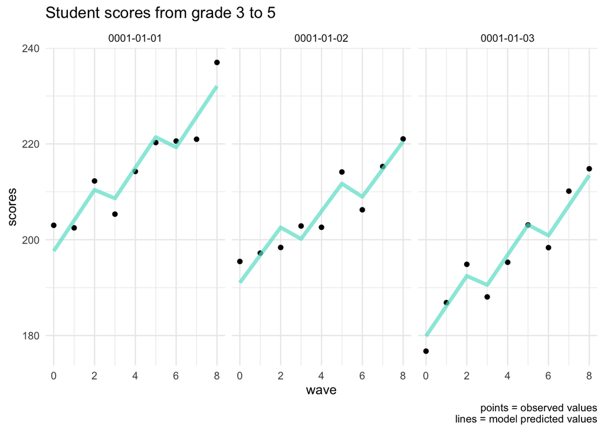

```r
plot_dat %>%
  ggplot(aes(group = sid)) +
  geom_point(
    aes(x = wave, y = scores)) +
  geom_line(
    aes(x = wave, y = prediction),
    color = '#67E0CF',
    alpha = 0.7,
    size = 1.5) +
  facet_wrap(~sid) +
  theme_minimal() +
  labs(title = 'Student scores from grade 3 to 5',
  caption = 'points = observed values
  lines = model predicted values')
```